# Practical Machine Learning

Aravind S

06/04/2020

# INTRODUCTION

This document is submitted as an assignment as a part of the course, “Practical Machine Learning” in Coursera

# BACKGROUND

Six young health participants were asked to perform one set of 10 repetitions of the Unilateral Dumbbell Biceps Curl in five different fashions: exactly according to the specification (Class A), throwing the elbows to the front (Class B), lifting the dumbbell only halfway (Class C), lowering the dumbbell only halfway (Class D) and throwing the hips to the front (Class E).

Class A corresponds to the specified execution of the exercise, while the other 4 classes correspond to common mistakes.

The aim of this exercise is to predict the type of activity being performed using the 4 different movements (Arm, Forear, Belt and Dumbell)

The weight lifting dataset was obtained from the source: http://web.archive.org/web/20161224072740/http:/groupware.les.inf.puc-rio.br/har

## LOADING THE REQUIRED LIBRARIES

```r
library(ggplot2)
library(caret)
library(e1071)
library(rattle)
library(kernlab)
library(RANN)
library(ISLR)
library(splines)
library(randomForest)
library(gbm)
library(data.table)
library(dplyr)
library(corrplot)
```

## READING THE DATASET

```r
setwd("D:\\Coursera\\Practical_Machine_Learning")
training <- as.data.frame(fread("pml-training.csv"))
dim(training)
```

```
## [1] 19622   160
```

# PREPROCESSING

Removing the columns serial numbers, name and time stamps since they cannot be used as an input to the model.

```r
training <- training[,-c(1:5)]
dim(training)
```

```
## [1] 19622   155
```

Removing columns which are mostly(>95%) NA and have Zero variance

```r
allna <- sapply(training,function(x) mean(is.na(x))) > 0.95
training <- training[,allna==FALSE]
NZV <- nearZeroVar(training)
training <- training[,-NZV]
dim(training)
```

```
## [1] 19622    54
```

Partitioning the data into 70% and 30% to build the model and test it

```r
inTrain  <- createDataPartition(training$classe, p=0.7, list=FALSE)
TrainSet <- training[inTrain, ]
TestSet  <- training[-inTrain, ]
dim(TrainSet)
```

```
## [1] 13737    54
```

```r
dim(TestSet)
```

```
## [1] 5885   54
```

Looking the correlation between the remaining 53 variables

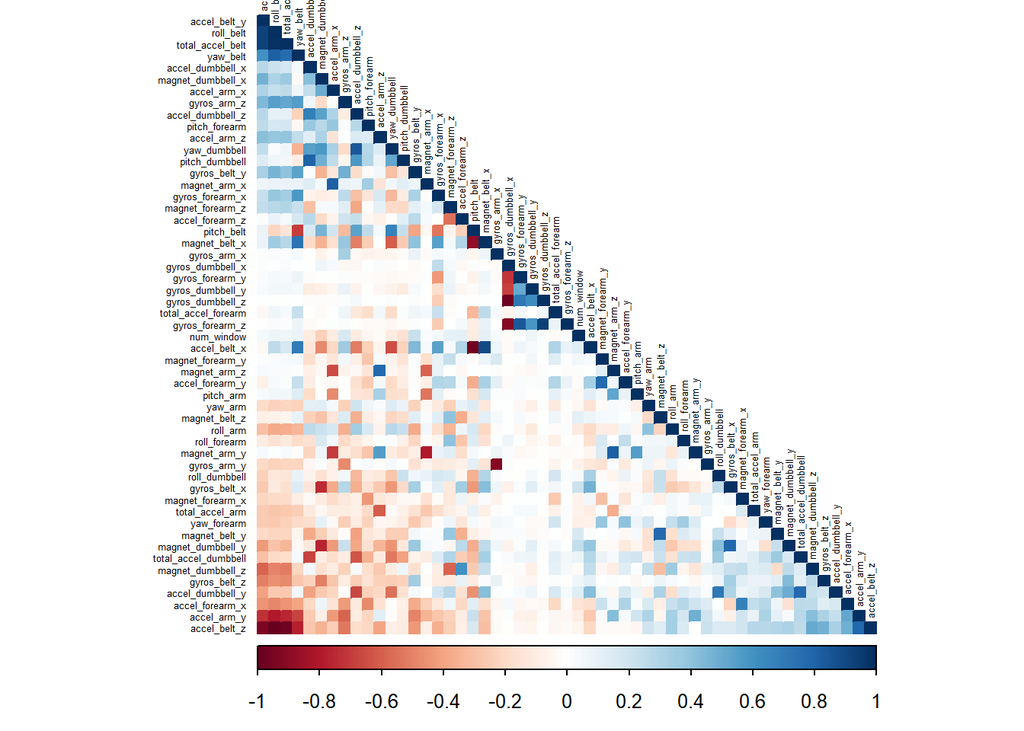

```r
cormatrix <- cor(training[,-54])
corrplot(cormatrix, order = "FPC", method = "color", type = "lower", tl.cex=0.4, tl.col=rgb(0,0,0))
```

# MODEL TRAINING

We shall try to fit the following models in the training data set

1. Decision Tree
2. Generalized Boosted Model
3. Random Forest

### DECISION TREE

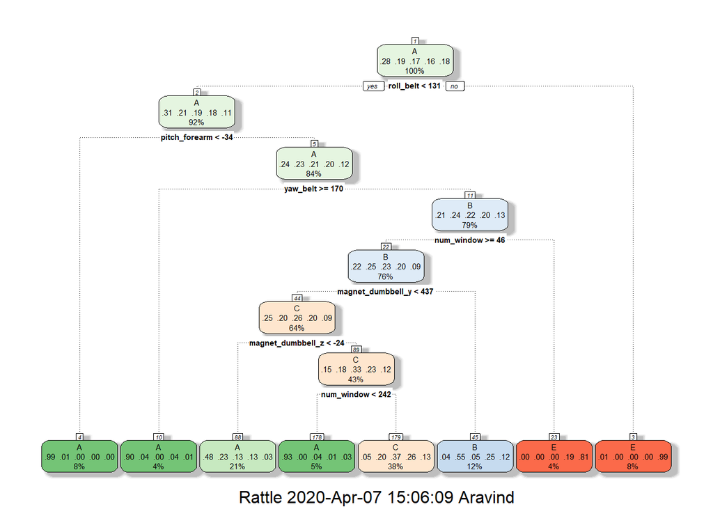

```r
#decision tree
decision_tree <- train(classe~.,method="rpart",data=TrainSet)

fancyRpartPlot(decision_tree$finalModel)
```

```r
predictDecTree <- predict(decision_tree, newdata=TestSet)
confMatDecTree <- confusionMatrix(predictDecTree, as.factor(TestSet$classe))
confMatDecTree
```

```
## Confusion Matrix and Statistics
##
##           Reference
## Prediction    A    B    C    D    E
##          A 1539  277  159  187   44
##          B   33  381   22  163   77
##          C  100  481  845  559  303
##          D    0    0    0    0    0
##          E    2    0    0   55  658
##
## Overall Statistics
##
##                Accuracy : 0.5816
##                  95% CI : (0.5689, 0.5943)
##     No Information Rate : 0.2845
##     P-Value [Acc > NIR] : < 2.2e-16
##
##                   Kappa : 0.4644
##
##  Mcnemar's Test P-Value : < 2.2e-16
##
## Statistics by Class:
##
##                      Class: A Class: B Class: C Class: D Class: E
## Sensitivity            0.9194  0.33450   0.8236   0.0000   0.6081
## Specificity            0.8416  0.93784   0.7030   1.0000   0.9881
## Pos Pred Value         0.6976  0.56361   0.3693      NaN   0.9203
## Neg Pred Value         0.9633  0.85448   0.9497   0.8362   0.9180
## Prevalence             0.2845  0.19354   0.1743   0.1638   0.1839
## Detection Rate         0.2615  0.06474   0.1436   0.0000   0.1118
## Detection Prevalence   0.3749  0.11487   0.3888   0.0000   0.1215
## Balanced Accuracy      0.8805  0.63617   0.7633   0.5000   0.7981
```

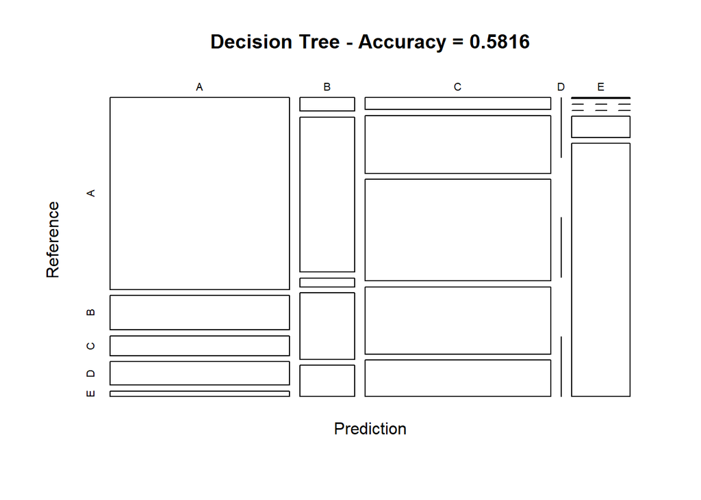

```r
plot(confMatDecTree$table, col = confMatDecTree$byClass,
     main = paste("Decision Tree - Accuracy =",
                  round(confMatDecTree$overall['Accuracy'], 4)))
```

### GENERALIZED BOOSTING MODEL

```r
controlGBM <- trainControl(method = "repeatedcv", number = 5, repeats = 1)
modFitGBM  <- train(classe ~ ., data=TrainSet, method = "gbm",
                    trControl = controlGBM, verbose = FALSE)
modFitGBM$finalModel
```

```
## A gradient boosted model with multinomial loss function.
## 150 iterations were performed.
## There were 53 predictors of which 53 had non-zero influence.
```

```r
predictGBM <- predict(modFitGBM, newdata=TestSet)
confMatGBM <- confusionMatrix(predictGBM, as.factor(TestSet$classe))
confMatGBM
```

```
## Confusion Matrix and Statistics
##
##           Reference
## Prediction    A    B    C    D    E
##          A 1669   10    0    0    0
##          B    5 1111    9    1    2
##          C    0   17 1010   17    4
##          D    0    1    7  945    6
##          E    0    0    0    1 1070
##
## Overall Statistics
##
##                Accuracy : 0.9864
##                  95% CI : (0.9831, 0.9892)
##     No Information Rate : 0.2845
##     P-Value [Acc > NIR] : < 2.2e-16
##
##                   Kappa : 0.9828
##
##  Mcnemar's Test P-Value : NA
##
## Statistics by Class:
##
##                      Class: A Class: B Class: C Class: D Class: E
## Sensitivity            0.9970   0.9754   0.9844   0.9803   0.9889
## Specificity            0.9976   0.9964   0.9922   0.9972   0.9998
## Pos Pred Value         0.9940   0.9849   0.9637   0.9854   0.9991
## Neg Pred Value         0.9988   0.9941   0.9967   0.9961   0.9975
## Prevalence             0.2845   0.1935   0.1743   0.1638   0.1839
## Detection Rate         0.2836   0.1888   0.1716   0.1606   0.1818
## Detection Prevalence   0.2853   0.1917   0.1781   0.1630   0.1820
## Balanced Accuracy      0.9973   0.9859   0.9883   0.9887   0.9944
```

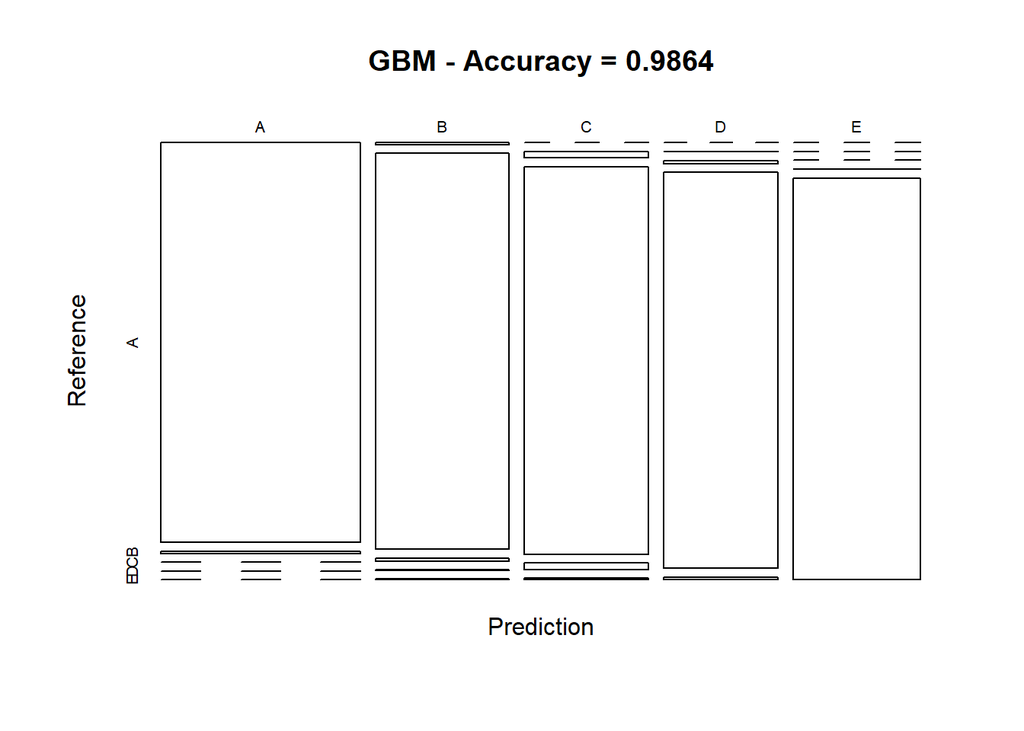

```r
plot(confMatGBM$table, col = confMatGBM$byClass,
     main = paste("GBM - Accuracy =", round(confMatGBM$overall['Accuracy'], 4)))
```

### RANDOM FOREST

```r
controlRF <- trainControl(method="cv", number=3, verboseIter=FALSE)
modFit <- train(classe~ .,data=TrainSet,method="rf",prox=TRUE,trControl=controlRF)
modFit$finalModel
```

```
##
## Call:
##  randomForest(x = x, y = y, mtry = param$mtry, proximity = TRUE)
##                Type of random forest: classification
##                      Number of trees: 500
## No. of variables tried at each split: 27
##
##         OOB estimate of  error rate: 0.21%
## Confusion matrix:
##      A    B    C    D    E  class.error
## A 3904    1    0    0    1 0.0005120328
## B    7 2648    3    0    0 0.0037622272
## C    0    4 2391    1    0 0.0020868114
## D    0    0    7 2245    0 0.0031083481
## E    0    1    0    4 2520 0.0019801980
```

```r
predictRandForest <- predict(modFit, newdata=TestSet)
confMatRandForest <- confusionMatrix(predictRandForest, as.factor(TestSet$classe))
confMatRandForest
```

```
## Confusion Matrix and Statistics
##
##           Reference
## Prediction    A    B    C    D    E
##          A 1674    4    0    0    0
##          B    0 1133    1    0    0
##          C    0    2 1025    3    0
##          D    0    0    0  960    3
##          E    0    0    0    1 1079
##
## Overall Statistics
##
##                Accuracy : 0.9976
##                  95% CI : (0.996, 0.9987)
##     No Information Rate : 0.2845
##     P-Value [Acc > NIR] : < 2.2e-16
##
##                   Kappa : 0.997
##
##  Mcnemar's Test P-Value : NA
##
## Statistics by Class:
##
##                      Class: A Class: B Class: C Class: D Class: E
## Sensitivity            1.0000   0.9947   0.9990   0.9959   0.9972
## Specificity            0.9991   0.9998   0.9990   0.9994   0.9998
## Pos Pred Value         0.9976   0.9991   0.9951   0.9969   0.9991
## Neg Pred Value         1.0000   0.9987   0.9998   0.9992   0.9994
## Prevalence             0.2845   0.1935   0.1743   0.1638   0.1839
## Detection Rate         0.2845   0.1925   0.1742   0.1631   0.1833
## Detection Prevalence   0.2851   0.1927   0.1750   0.1636   0.1835
## Balanced Accuracy      0.9995   0.9973   0.9990   0.9976   0.9985
```

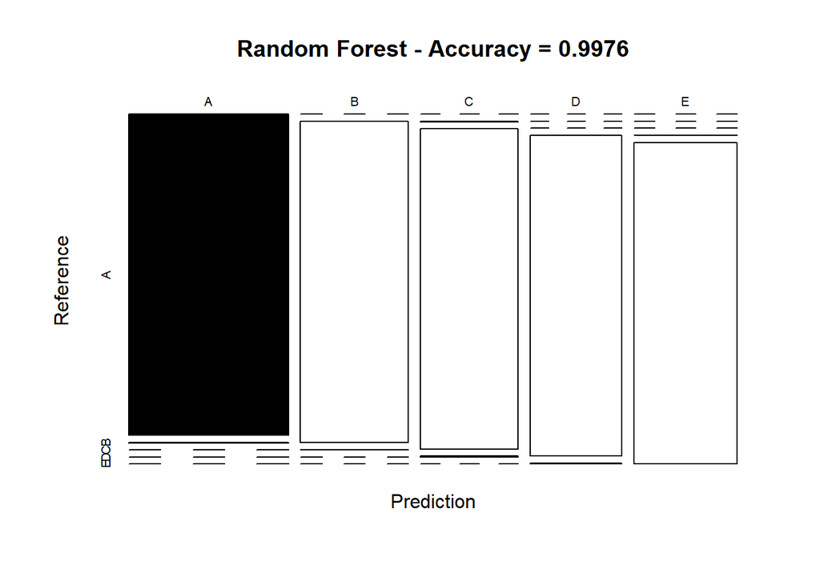

```r
# plot matrix results
plot(confMatRandForest$table, col = confMatRandForest$byClass,
     main = paste("Random Forest - Accuracy =",
                  round(confMatRandForest$overall['Accuracy'], 4)))
```

Random Forest is going to be used to predict the dataset for the quiz